# ECO 411/511 - Unit 1 - Introduction, What is Causal Inference?

James Flynn

August 24, 2026

## ECO 411/511 - Advanced Empirical Methods

This course will:

- Introduce you to the modern empirical methods used to conduct research in economics.
- Build skills that are useful in industry, government and academic settings
- Include a strong focus on empirical programming skills using R
- Pre-reqs: Eco 311 and Eco 315

## Roadmap for the semester - First Half

We are going to cover *a lot* of ground. First half:

- Intro to R coding, project management, data visualization
- Regression review, getting causality from regression
- Modeling: causal diagrams and potential outcomes
- Simulations and standard errors

Then Midterm 1

## Roadmap for the semester - Second Half

The second half is all about methodologies:

- Panel data
- Diff-in-diff, event-study, synthetic control
- Instrumental variables
- Regression discontinuity designs

Final exam

## What the heck is causal inference?

- This is a class about **causal inference**
- Wikipedia Definition
  - Causal Inference is the process of determining the independent, actual effect of a particular phenomenon that is a component of a larger system.
  - This means moving past simple *correlations* to find what *causes* what
  - Effective causal inference methods can be difficult to implement, but can offer compelling evidence

## Causal Inference

- We know that
  $$Correlation \neq
  Causation$$
- So what does equal causation??

## Causal Inference

- It turns out that
- $$Correlation + Assumptions =
  Causation$$

## Causal Inference (cont’d)

- Most interesting questions require causal inference:
- Why are these hard questions to answer?
  - Does getting more sleep make you earn more money? ([Costa-Font et al, (2024)](https://www.sciencedirect.com/science/article/pii/S0167629623001170))
  - Does getting diagnosed with Diabetes cause people to adopt healthier habits? ([Alalouf et al (2024)](https://www.journals.uchicago.edu/doi/10.1086/724415))
  - Are judges harsher on juveniles when their favorite football team loses? ([Eren and Mocan (2017)](https://www.aeaweb.org/articles?id=10.1257/app.20160390))

## Interest in causal inference is growing

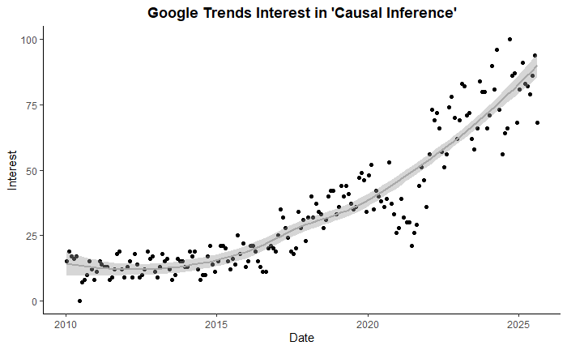

## How did I do that?

```r
library(tidyverse)
google_trends <- read.csv("google_trends_causal_inf_2025.csv") %>%
  mutate(date = as.Date(paste(year,month,15,sep="-")))

causal_inf_graph <- ggplot(google_trends, aes(x=date,y=interest)) +
  geom_point() +
  geom_smooth(method = "loess", se = TRUE, color = "darkgray") +
  ylab("Interest") +
  xlab("Date") +
  theme_classic() +
   theme(plot.title = element_text(hjust = 0.5, face = "bold")) +
  ggtitle("Google Trends Interest in 'Causal Inference'")
```

## Here’s the result

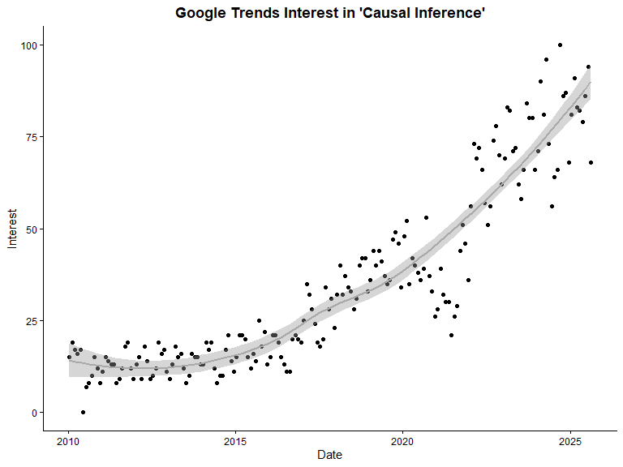

## Why is Causal Inference Hard?

- We have unprecedented amounts of data
- Lots of tools at our disposal

## The Experimental Ideal

- Randomized Controlled Trials (RCT) are considered the *gold standard* in causal inference
  - Why is that?

## What is an RCT?

- Let’s say you have a new miracle drug that you think will cure halitosis (bad breath) in all humans.
- How can you prove it works?
  - Recruit a bunch of participants with bad breath
  - Want to give drug to some and a *placebo* to others
  - How do we decide who gets the drug?

## Randomization is the Secret Sauce

- If you randomly choose who to give the drug to, the only difference between the two groups is the treatment!
- Otherwise, there can always be another explanation
  - What if we gave the drug to the people with the worst breath?
  - The best breath (among the bad breath group)
  - Just the men?
- All of these strategies open up **back doors** which can prevent us from drawing causal conclusions

## What do we mean by **back door**?

- A **back door** is another explanation for why outcomes diverged between the treatment and control groups
- When the groups are different in many ways, there are lots of back doors
- Example: does getting more education lead to higher wages?
  - What are the back doors here?

## Randomization closes back doors

- Randomization guarantees that our treated group looks just like our control group
- But how?
- LLN
- Need a large enough sample
- Can even check to make sure randomization worked

## With an RCT, we don’t need fancy econometrics

- All the hard work is done up front
- Usually just a simple regression
- Bannerjee and Duflo, John List, and many others do great experiments
- Why not use RCTs for everything then?

## Limitations of RCTs

- Not always feasible ($$$)
- Not always ethical
- People act differently in experiments
  - Participant bias
  - Social desirability bias
- May not be generalizable to other populations

## Wrapping up RCTs

- Despite limitations, RCTs are the **gold standard**
- Provide convincing evidence that a treatment **caused** an outcome
- Help policymakers make informed decisions
- Even when RCT is not feasible, it is usually worth thinking about what kind of experiment you would run if you had unlimited funds and no moral compass

## So how do we do causal inference with no RCT?

- With no RCT, we often try to find settings where treatment ends up getting assigned in a relatively random way.
- Often called **natural experiments**
- Like RCTs, these have benefits and drawbacks

## Natural experiments - benefits

- Free from the biases that exist in RCTs
- Allow us to answer questions that would be impossible to do an RCT on
- Can sometimes be more generalizable
- Involve observational data from the real world

## Natural experiments - drawbacks

- Selection bias
- Omitted variable bias
- Reverse causality
- Correlation $\neq$ causation

This class is all about how we can overcome these issues by being clever with data

## Selection Bias Plane

[figure not shown]

## Selection Bias

[figure not shown]

## Omitted Variable Bias

[figure not shown]

## Reverse Causality

[figure not shown]

## Correlation vs. Causation

[figure not shown]

## Strategies for making causal claims with no RCT

- Controlling for omitted variables
- Differences-in-differences
- Instrumental variables
- Regression discontinuity

Many others, but these are the big ones

## Our plans

For each of these strategies, we will learn:

- Why they allow us to make causal claims
- The assumptions we need to make in order to do so
- How to implement them in R

We will start by building **intuition**, then focus on mechanics

## Starting with a research question

- Before we can use these methods, we need a research question
- What makes a good research question?
  - Something that can be answered with the right data
  - If answered, it should teach us something interesting about the world

## Which of these satisfies both requirements?

- Are there more male surgeons than female surgeons?
- Do med school professors intentionally discourage women from becoming surgeons?
- Are female surgeons punished more harshly than male surgeons for making mistakes?*

*See Sarsons (2017) for the answer

## So how do we come up with good research questions?

- If you figure this out, let me know!
- Good questions can come from many sources:
  - Newspapers and local news
  - Other research (pick a field journal)
  - Conferences
  - Maybe you have a cool dataset
  - Hear about a nice natural experiment

Reason we focus on intuition in this class is that I want you to build an internal radar that goes off when you hear about something that could be a nice research design

## Where can we get data to answer our questions?

- Publicly available data (see class website)
- Replication packages (AEA papers)
- Restricted-access data (Census, NCHS, etc.)
- Create your own!
  - Merging datasets together
  - Google Trends, Twitter
  - Web-scraping

## R - What is it good for?

We will be using R exclusively in this class

- Why R and not STATA?
  - STATA useful in academic economics, but almost nowhere else
  - R is more versatile and growing rapidly
  - R is open-source (free)
  - R is much better at working with the internet (scraping, R-Shiny)

## R Studio

R Studio is an application that makes it **much** easier to use R

[figure not shown]

## Goals of this class

- Learn modern methods for causal inference
  - Develop understanding of **identification**
  - Build your `exogenous variation` internal radar
- Build your technical skillset in R
  - Learn to implement these methods
  - Develop coding best practices
- Figure out if you want to do economic research
  - I will try to show you what doing research is like
  - Ins and outs of the publishing process
  - This class is a chance to try on your `researcher hat`